# DAB 501 - Assignment 3

## Exercise 6

**6) What characteristics correspond to an evolved Pokémon with a high combat power? You do not need to come up with an exhaustive list, but you should walk us through your reasoning for answering this question and include all relevant summary statistics and visualizations.**

**1) Change in various characteristics**

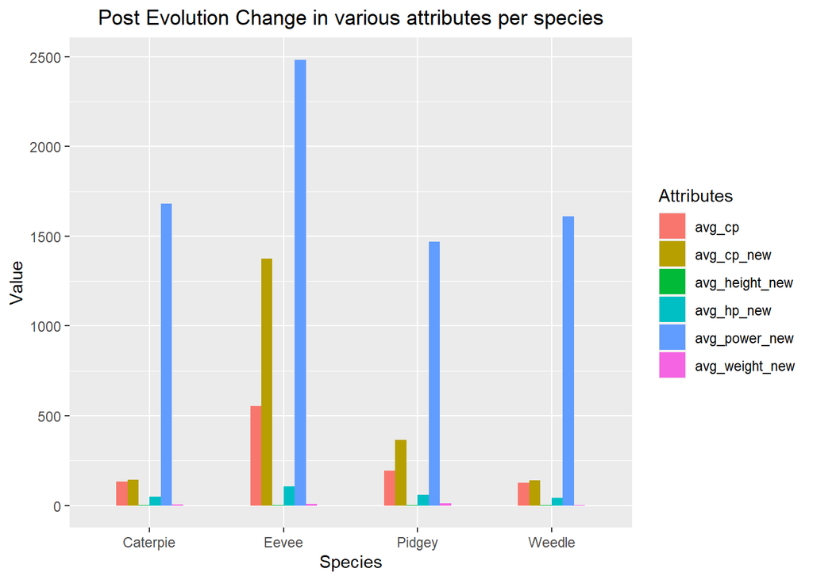

```r
df %>%
  group_by(species) %>%
   summarise(
          avg_cp= mean(cp),
          avg_cp_new= mean(cp_new),
          avg_height_new = mean(height_new),
          avg_weight_new = mean(weight_new),
          avg_hp_new = mean(hp_new),
          avg_power_new = mean(power_up_stardust_new)) %>%
   gather(`avg_cp`,`avg_cp_new`,`avg_height_new`,`avg_weight_new`,`avg_hp_new`,`avg_power_new` ,key="attribute", value="value") %>%
  ggplot() +
      geom_col(aes(x=species, fill=attribute, y=value), position='dodge', width=0.5)+
  ggtitle("Post Evolution Change in various attributes per species") +
  labs(x = "Species", y = "Value", fill="Attributes") + theme(plot.title = element_text (hjust = 0.5))
```

**2) Zooming into Powerdust analysis**

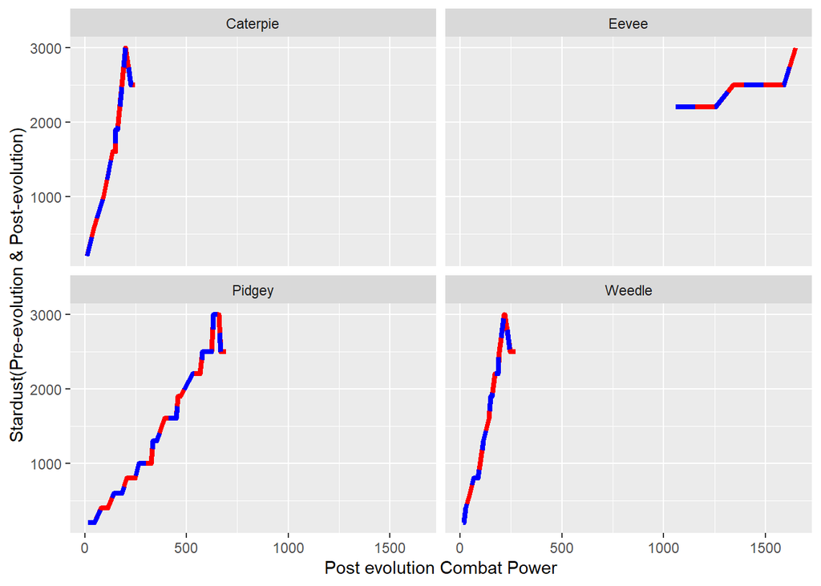

```r
ggplot() +
  geom_line(data=df, aes(x=cp_new, y = power_up_stardust), color = "red", size=1.5) +
  geom_line(data=df, aes(x=cp_new, y = power_up_stardust_new), color="Blue", linetype="dashed", size=1.5) +
  facet_wrap(~species, nrow=2,ncol=2) +
  labs(x= "Post evolution Combat Power", y = "Stardust(Pre-evolution & Post-evolution)")
```

**3) Change in Strong attack values**

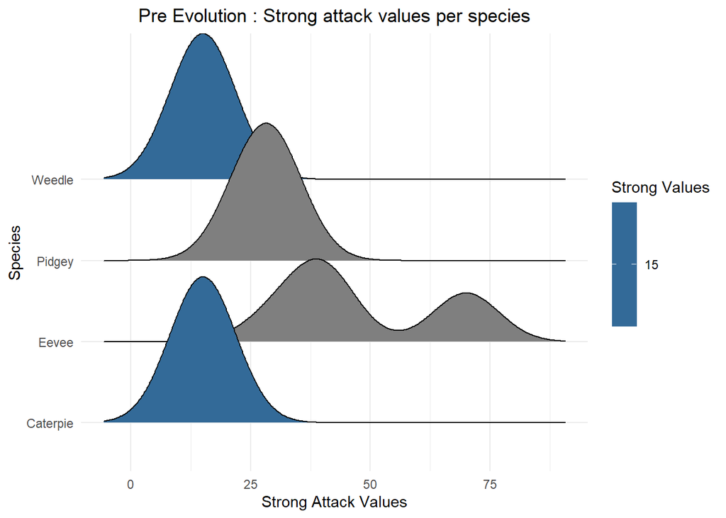

```r
ggplot(df,
       aes(x = attack_strong_value,
           y = species,
           fill = attack_strong_value)) +
  geom_density_ridges() +
  theme_ridges() +
  labs("Highway mileage by auto class") +
  theme(legend.position = "none")+
  labs(title = "Pre Evolution : Strong attack values per species",
       x = "Strong Attack Values",
       y = "Species", fill = "Strong Values")+
  theme_minimal()+ theme(plot.title = element_text (hjust = 0.5))
```

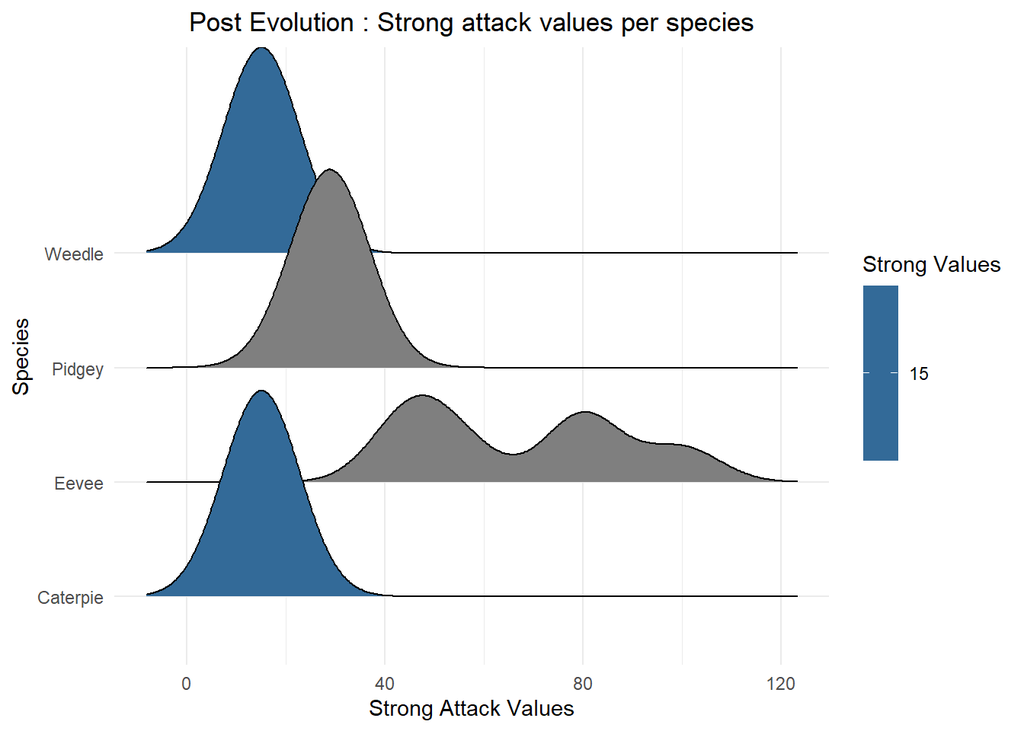

```r
ggplot(df,
       aes(x = attack_strong_value_new,
           y = species,
           fill = attack_strong_value_new)) +
  geom_density_ridges() +
  theme_ridges() +
  theme(legend.position = "none") +
  labs(title = "Post Evolution : Strong attack values per species",
       x = "Strong Attack Values",
       y = "Species", fill = "Strong Values")+
  theme_minimal()+ theme(plot.title = element_text (hjust = 0.5))
```

Post evolution: we do not witness much change in the attack values.  
Inspite of highest power dust values, the strong attack values seems to have increased slightly.